# Population Genetics Analysis of Arabidopsis thaliana

Contents

- Overview
- Practical Setup: Running Analysis on HPC
- Conceptual and Statistical Rationale
- 0. Required Packages
- 1. Load and Process FST Data
- 2. Visualise FST Distribution
- 3. Gene Annotation and SNP-to-Gene Mapping
- 4. Identify Candidate Genes
- 5. GO Enrichment Analysis
- 6. Interactive GO Enrichment Table
- 7. Visualisation of Enriched GO Terms
- 9. Analysis Summary

# Population Genetics Analysis of Arabidopsis thaliana

Practical Session 6 - Gene Ontology (GO) Enrichment for Climate Adaptation Genes

Dr Tahir Ali | AG de Meaux

December 19, 2025

**Set up the path to the working directory**

```r
# Set the knitr root directory - this PERSISTS
# replace qbiad019 with Your_USER_NAME
knitr::opts_knit$set(root.dir = "/home/group.kurse/qbiad019/Practical_Session_6/")

# Also set DATA_DIR variable for reference
DATA_DIR <- "/home/group.kurse/qbiad019/Practical_Session_6/"

cat("Knitr root.dir set to:", knitr::opts_knit$get("root.dir"), "\n")
```

```
## Knitr root.dir set to: /home/group.kurse/qbiad019/Practical_Session_6/
```

```r
cat("Files available:", paste(list.files()[1:3], collapse=", "), "\n")
```

```
## Files available: Login_2_RAMSES_Start_RStudio_Server.pdf, Practical_Day_6.qmd, Practical_Day_6.zip
```

# Overview

This pipeline identifies biological processes under divergent selection between Swedish (SWE) and Spanish (ESP) *Arabidopsis* populations. The analysis proceeds from SNP-level population differentiation (FST) to gene-level aggregation and Gene Ontology (GO) enrichment, with explicit attention to assumptions, limitations, and best practices.

The workflow is designed to answer the question:

> *Are specific biological processes enriched among genes showing unusually high population differentiation between climatically distinct populations?*

# Practical Setup: Running Analysis on HPC

## Instructions for Running Bioinformatics Jobs on the HPC (RAMSES)

### Basic Steps:

**Step 0.** Copy the required directory to your home directory (Change qbiad019 with Your_User_Name)

```bash
cp -r /scratch/qbio/Practical_Session_6 /home/group.kurse/qbiad019
```

**Step 1.** Open a text editor and create the file:

```bash
nano stacks.sh
```

**Step 2.** Copy the entire script below `stacks.sh` and paste it into nano:

**Step 3:** Save and Exit Nano

Press Ctrl + X to exit

Press Y to confirm saving

Press Enter to keep the filename stacks.sh

**Step 4.** Submit Your Job In the terminal, run:

```bash
sbatch stacks.sh
```

**For more details**, consult the [RAMSES Brief Instructions](https://gitlab.git.nrw/uzk-itcc-hpc/itcc-hpc-ramses/-/wikis/Documentation)

### Estimating Genome-wide FST Values

To conduct this analysis, we require an estimate of genome-wide FST values to measure genetic differentiation between two groups (populations) of samples, using variants provided in a VCF file. For the estimation of genome-wide FST, we will use the software **STACKS**.

### Create and Submit a SLURM Script for estimating Genome-wide FST values

First, check if the required module is installed:

```bash
module avail
module avail bio/
```

**Double check before submitting job if your all input files exist:**

```bash
# Verify your input files exist
ls -la "/home/group.kurse/qbiad019/Practical_Session_6/vcf/1001genomes_snp-short-indel_only_ACGTN_Dp10GQ20Q30_NoIndel_Bialleleic_80PcMissing_80SwEs.vcf.recode.vcf.gz"

ls -la "/home/group.kurse/qbiad019/Practical_Session_6/vcf/1001genomes_snp-short-indel_only_ACGTN_Dp10GQ20Q30_NoIndel_Bialleleic_80PcMissing_80SwEs_DefenseOnly.vcf.gz"

# Check if popmap file exists
ls -la "/home/group.kurse/qbiad019/Practical_Session_6/stacks/pop.txt"
```

#### Example SLURM Script (`stacks.sh`):

```bash
#!/bin/bash -l

#SBATCH --job-name=stacks
#SBATCH --nodes=1
#SBATCH --ntasks-per-node=8
#SBATCH --mem=100gb
#SBATCH --time=01:00:00
#SBATCH --account=kurse
#SBATCH --error=/home/group.kurse/qbiad019/Practical_Session_6/stacks/stacks_pop.err
#SBATCH --output=/home/group.kurse/qbiad019/Practical_Session_6/stacks/stacks_pop.out

# Load the stacks module
module load bio/Stacks/2.62-foss-2022a

# Input directory
input_dir="/home/group.kurse/qbiad019/Practical_Session_6/vcf"

# Output directory
output_dir="/home/group.kurse/qbiad019/Practical_Session_6/stacks"

mkdir -p "$output_dir"

populations -V "${input_dir}/1001genomes_snp-short-indel_only_ACGTN_Dp10GQ20Q30_NoIndel_Bialleleic_80PcMissing_80SwEs.vcf.recode.vcf.gz" \
            --popmap "/home/group.kurse/qbiad019/Practical_Session_6/stacks/pop.txt" \
            --fstats -t 10 --structure -O "${output_dir}"

populations -V "${input_dir}/1001genomes_snp-short-indel_only_ACGTN_Dp10GQ20Q30_NoIndel_Bialleleic_80PcMissing_80SwEs_DefenseOnly.vcf.gz" \
            --popmap "/home/group.kurse/qbiad019/Practical_Session_6/stacks/pop.txt" \
            --fstats -t 10 --structure -O "${output_dir}"
```

### Check Status and ID of Your Submitted Job:

```bash
squeue -u Your_User_Name
```

### To Cancel Running Job:

```bash
scancel Your_Job_ID
```

**Note:** This practical session assumes the FST analysis has already been completed using the above workflow. We will now proceed with the downstream GO enrichment analysis using the generated FST statistics.

# Conceptual and Statistical Rationale

## Why FST Outliers?

FST measures allele frequency differentiation between populations. Under neutrality, most loci are expected to show modest differentiation shaped by drift and shared demographic history. Loci in the extreme upper tail of the FST distribution are candidates for divergent selection, particularly when populations inhabit contrasting environments (e.g.Sweden vs Spain).

**Key assumption:** The right tail of the empirical FST distribution is enriched for loci influenced by selection, although demography and linked selection may also contribute.

## Why Gene-Level and GO Enrichment?

Selection acts on phenotypes encoded by genes and pathways rather than isolated SNPs. Aggregating SNPs to genes and testing for GO term enrichment allows:

- Increased biological interpretability
- Detection of pathway-level signals even when individual SNP effects are modest
- Explicit hypothesis testing against a genome-wide background

## Important Caveat (Avoiding Circularity)

GO enrichment must always use an appropriate *gene universe*. Restricting the background to a pre-filtered functional subset (e.g.only defense genes) risks circular inference and inflated significance. In this pipeline:

- **Outlier detection** is genome-wide
- **GO enrichment background** consists of all genes with at least one tested SNP

# 0. Required Packages

The following packages are required for the analysis and plotting

```r
cat("Loading required packages...\n")
```

```r
required_packages <- c("topGO", "org.At.tair.db", "ggplot2", "dplyr",
                       "tidyr", "stringr", "GenomicRanges", "readr", "DT")
invisible(lapply(required_packages, function(pkg) {
  if(!require(pkg, character.only = TRUE, quietly = TRUE)) {
    install.packages(pkg, dependencies = TRUE)
    library(pkg, character.only = TRUE)
  }
}))
```

# 1. Load and Process FST Data

- **PURPOSE:** Load population differentiation statistics to identify loci under divergent selection between populations
- **BIOLOGICAL LOGIC:** FST measures genetic differentiation between populations.
- **High FST values** indicate loci with allele frequency differences greater than expected under neutral evolution, suggesting selection.
- **STATISTICAL LOGIC:** Using percentile thresholds (e.g., top 5%) identifies outliers from the neutral expectation distribution.

```r
cat("Setting up analysis parameters...\n")
```

```
## Setting up analysis parameters...
```

```r
config <- list(
  fst_quantile = 0.95,     # Top 5% FST threshold (95th percentile)
# pval_threshold = 0.05,    # For GO analysis gene selection
  node_size = 10,           # Min genes per GO term
  top_terms = 10,           # Top terms to display in plots
  algorithm = "elim",       # GO algorithm
  ontology = "BP"           # Biological Process ontology
)

cat("\nStep 1: Loading and processing FST data...\n")
```

```
##
## Step 1: Loading and processing FST data...
```

```r
fst_file <- "/home/group.kurse/qbiad019/Practical_Session_6/stacks/1001genomes_snp-short-indel_only_ACGTN_Dp10GQ20Q30_NoIndel_Bialleleic_80PcMissing_80SwEs.vcf.recode.p.fst_SWE-ESP.tsv"

fstats <- read.table(
  fst_file,
  header = FALSE,
  sep = "\t",
  comment.char = "#",
  fill = TRUE,
  quote = ""
)

colnames(fstats) <- c(
  "Locus_ID","Pop1_ID","Pop2_ID","Chr","BP","Column",
  "Fishers_P","Odds_Ratio","CI_Low","CI_High",
  "LOD","AMOVA_Fst","Smoothed_AMOVA_Fst",
  "Smoothed_AMOVA_Fst_Pvalue"
)

fst_data <- data.frame(
  Chr = fstats$Chr,
  BP = fstats$BP,
  FST = fstats$AMOVA_Fst,
  Fisher_P = fstats$Fishers_P
)

fst_data <- fst_data[!is.na(fst_data$FST), ]

cat("  Total SNPs analyzed:", nrow(fst_data), "\n")
```

```
##   Total SNPs analyzed: 648916
```

```r
cat("  FST range:", round(range(fst_data$FST), 3), "\n")
```

```
##   FST range: 0 0.797
```

```r
cat("  Mean FST:", round(mean(fst_data$FST), 4), "\n")
```

```
##   Mean FST: 0.0391
```

# 2. Visualise FST Distribution

```r
cat("\nStep 2: Plotting FST distribution...\n")
```

```
##
## Step 2: Plotting FST distribution...
```

```r
fst_threshold <- quantile(fst_data$FST, config$fst_quantile, na.rm = TRUE)
cat("  Top 5% FST threshold:", round(fst_threshold, 4), "\n")
```

```
##   Top 5% FST threshold: 0.1372
```

```r
cat("  SNPs above threshold:", sum(fst_data$FST >= fst_threshold, na.rm = TRUE), "\n")
```

```
##   SNPs above threshold: 32463
```

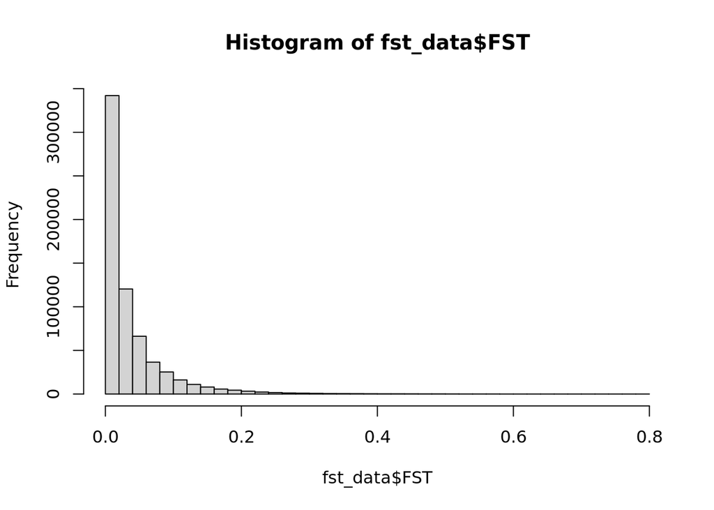

```r
p_fst_dist <- ggplot(fst_data, aes(x = FST)) +
  geom_histogram(bins = 50, fill = "steelblue", alpha = 0.7, color = "white") +
  geom_vline(xintercept = fst_threshold,
             linetype = "dashed", color = "red", linewidth = 1) +
  annotate("text", x = fst_threshold * 1.1, y = max(hist(fst_data$FST, breaks = 50)$counts),
           label = paste("Top 5%\nFST >", round(fst_threshold, 3)),
           color = "red", size = 4, fontface = "bold", hjust = 0) +
  labs(
    title = "Distribution of FST Values (SWE vs ESP)",
    subtitle = "Red line indicates top 5% threshold for candidate selection",
    x = "FST Value",
    y = "Number of SNPs"
  ) +
  theme_minimal(base_size = 12) +
  theme(
    panel.grid.major = element_line(color = "gray90"),
    panel.grid.minor = element_blank(),
    plot.title = element_text(face = "bold", hjust = 0.5),
    plot.subtitle = element_text(color = "gray40", hjust = 0.5)
  )
```

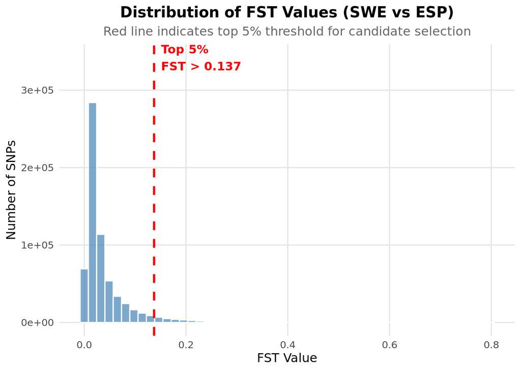

```r
print(p_fst_dist)
```

# 3. Gene Annotation and SNP-to-Gene Mapping

- **PURPOSE:** Link genomic positions to gene annotations for functional analysis
- **BIOLOGICAL LOGIC:** Selection acts on phenotypes, which are determined by genes. **Mapping SNPs to genes** connects genetic variation to biological function.
- **STATISTICAL LOGIC:** Using genomic ranges ensures accurate positional mapping, handling gene boundaries and overlapping features correctly.

```r
cat("\nStep 3.1: Loading and parsing annotation file...\n")
```

```
##
## Step 3.1: Loading and parsing annotation file...
```

```r
# Load annotation file with your known column structure
annot <- read.delim("vcf/GFF_final_with_annotation_2_gff", header = FALSE, comment.char = "#")
# Check the actual number of columns
cat("  Columns in file:", ncol(annot), "\n")
```

```
##   Columns in file: 15
```

```r
cat("  Rows in file:", nrow(annot), "\n")
```

```
##   Rows in file: 28813
```

```r
# Assign column names for ALL 15 columns
colnames(annot) <- c(
  "gene_id", "chr", "tair_version", "type", "start", "end", "empty1",
  "strand", "empty2", "gene_id2", "gene_id3", "type_name", "short_description",
  "curation", "extra_column"  # Added 15th column
)

# Clean up gene IDs (they're already in the first column)
annot$gene_id_clean <- annot$gene_id

# Remove version numbers (e.g., .1, .2) if present
annot$gene_id_clean <- sub("\\.\\d+$", "", annot$gene_id_clean)

# Also check other gene ID columns
if(any(!is.na(annot$gene_id2))) {
  annot$gene_id_clean[is.na(annot$gene_id_clean)] <- annot$gene_id2[is.na(annot$gene_id_clean)]
  annot$gene_id_clean <- sub("\\.\\d+$", "", annot$gene_id_clean)
}

if(any(!is.na(annot$gene_id3))) {
  annot$gene_id_clean[is.na(annot$gene_id_clean)] <- annot$gene_id3[is.na(annot$gene_id_clean)]
  annot$gene_id_clean <- sub("\\.\\d+$", "", annot$gene_id_clean)
}

# Check what we have
cat("\n  Gene ID extraction results:\n")
```

```
##
##   Gene ID extraction results:
```

```r
cat("    Unique clean gene IDs:", length(unique(annot$gene_id_clean)), "\n")
```

```
##     Unique clean gene IDs: 22360
```

```r
cat("    Sample gene IDs:", head(unique(annot$gene_id_clean), 5), "\n")
```

```
##     Sample gene IDs: Model_name AT1G01010 AT1G01020 AT1G01030 AT1G01040
```

```r
cat("    Gene types:", table(annot$type), "\n")
```

```
##     Gene types: 28812 1
```

```r
# Filter for gene features (based on 'type' column)
gene_types <- c("gene", "mRNA", "transcript", "CDS", "exon", "five_prime_UTR", "three_prime_UTR")
gene_features <- annot[annot$type %in% gene_types, ]

cat("\n  Gene features filtered:\n")
```

```
##
##   Gene features filtered:
```

```r
cat("    Total gene features:", nrow(gene_features), "\n")
```

```
##     Total gene features: 28812
```

```r
cat("    Unique genes in features:", length(unique(gene_features$gene_id_clean)), "\n")
```

```
##     Unique genes in features: 22359
```

```r
# Convert start and end to numeric
gene_features$start <- as.numeric(gene_features$start)
gene_features$end <- as.numeric(gene_features$end)

# For each gene, we need to find the full genomic range
# This handles cases where genes have multiple transcripts/exons
library(dplyr)

gene_ranges <- gene_features %>%
  group_by(gene_id_clean, chr) %>%
  summarise(
    start = min(start, na.rm = TRUE),
    end = max(end, na.rm = TRUE),
    .groups = 'drop'
  )

# Clean chromosome names
gene_ranges$chr <- sub("Chr", "", gene_ranges$chr)

# Remove any rows with NA values
gene_ranges <- gene_ranges[!is.na(gene_ranges$start) & !is.na(gene_ranges$end), ]

cat("\n  Final gene ranges:\n")
```

```
##
##   Final gene ranges:
```

```r
cat("    Total genes with ranges:", nrow(gene_ranges), "\n")
```

```
##     Total genes with ranges: 22359
```

```r
cat("    Sample ranges:\n")
```

```
##     Sample ranges:
```

```r
print(head(gene_ranges, 3))
```

```
## # A tibble: 3 × 4
##   gene_id_clean chr   start   end
##   <chr>         <chr> <dbl> <dbl>
## 1 AT1G01010     1      3631  5899
## 2 AT1G01020     1      5928  8737
## 3 AT1G01030     1     11649 13714
```

```r
# ---------------------------
# 3.2. CREATE GRANGES OBJECTS
# ---------------------------
cat("\nStep 3.2: Creating GRanges objects...\n")
```

```
##
## Step 3.2: Creating GRanges objects...
```

```r
# Create GRanges for FST SNPs
gr_fst <- GRanges(
  seqnames = fst_data$Chr,
  ranges = IRanges(start = fst_data$BP, end = fst_data$BP),
  FST = fst_data$FST,
  is_candidate = fst_data$FST >= fst_threshold
)

# Create GRanges for genes
gr_genes <- GRanges(
  seqnames = gene_ranges$chr,
  ranges = IRanges(start = gene_ranges$start, end = gene_ranges$end),
  gene_id = gene_ranges$gene_id_clean
)

cat("  FST SNPs in GRanges:", length(gr_fst), "\n")
```

```
##   FST SNPs in GRanges: 648916
```

```r
cat("  Genes in GRanges:", length(gr_genes), "\n")
```

```
##   Genes in GRanges: 22359
```

```r
# ---------------------------
# 3.3. FIND OVERLAPS
# ---------------------------
cat("\nStep 3.3: Finding overlaps between SNPs and genes...\n")
```

```
##
## Step 3.3: Finding overlaps between SNPs and genes...
```

```r
# Find overlaps
overlaps <- findOverlaps(gr_fst, gr_genes, type = "any", ignore.strand = TRUE)

cat("  Total overlaps found:", length(overlaps), "\n")
```

```
##   Total overlaps found: 409705
```

```r
if(length(overlaps) > 0) {
  cat("  Unique SNPs overlapping genes:", length(unique(queryHits(overlaps))), "\n")
  cat("  Unique genes with overlapping SNPs:", length(unique(subjectHits(overlaps))), "\n")

  # Create mapping table
  snp_gene_map <- data.frame(
    gene_id = gene_ranges$gene_id_clean[subjectHits(overlaps)],
    FST = fst_data$FST[queryHits(overlaps)],
    BP = fst_data$BP[queryHits(overlaps)],
    Chr = fst_data$Chr[queryHits(overlaps)],
    is_candidate = fst_data$FST[queryHits(overlaps)] >= fst_threshold
  )

  # Check the mapping
  cat("\n  SNP-gene mapping summary:\n")
  cat("    Total SNP-gene pairs:", nrow(snp_gene_map), "\n")
  cat("    Unique genes mapped:", length(unique(snp_gene_map$gene_id)), "\n")

  if(nrow(snp_gene_map) > 0) {
    snps_per_gene <- table(snp_gene_map$gene_id)
    cat("    Average SNPs per gene:", round(mean(snps_per_gene), 2), "\n")
    cat("    Candidate SNPs (FST ≥", round(fst_threshold, 4), "):",
        sum(snp_gene_map$is_candidate), "\n")

    # Display first few mappings
    cat("\n    First few SNP-gene mappings:\n")
    print(head(snp_gene_map, 5))
  }

} else {
  cat("  WARNING: No overlaps found between SNPs and genes!\n")
  cat("  Checking chromosome naming...\n")

  # Diagnostic: Check chromosome names
  unique_fst_chr <- unique(fst_data$Chr)
  unique_gene_chr <- unique(gene_ranges$chr)

  cat("    FST chromosomes:", head(unique_fst_chr, 10), "\n")
  cat("    Gene chromosomes:", head(unique_gene_chr, 10), "\n")

  # Try alternative chromosome naming
  cat("  Trying alternative chromosome naming...\n")

  # Standardize chromosome names
  fst_data$Chr_clean <- sub("^chr", "", fst_data$Chr, ignore.case = TRUE)
  fst_data$Chr_clean <- sub("^Chr", "", fst_data$Chr_clean)
  fst_data$Chr_clean <- sub("^0", "", fst_data$Chr_clean)  # Remove leading zeros

  # Create new GRanges with cleaned chromosome names
  gr_fst_clean <- GRanges(
    seqnames = fst_data$Chr_clean,
    ranges = IRanges(start = fst_data$BP, end = fst_data$BP),
    FST = fst_data$FST,
    is_candidate = fst_data$FST >= fst_threshold
  )

  # Try overlap again
  overlaps <- findOverlaps(gr_fst_clean, gr_genes, type = "any", ignore.strand = TRUE)
  cat("  Overlaps after chromosome cleaning:", length(overlaps), "\n")

  if(length(overlaps) > 0) {
    # Create mapping table with cleaned chromosomes
    snp_gene_map <- data.frame(
      gene_id = gene_ranges$gene_id_clean[subjectHits(overlaps)],
      FST = fst_data$FST[queryHits(overlaps)],
      BP = fst_data$BP[queryHits(overlaps)],
      Chr = fst_data$Chr_clean[queryHits(overlaps)],
      is_candidate = fst_data$FST[queryHits(overlaps)] >= fst_threshold
    )

    cat("\n  SNP-gene mapping after chromosome cleaning:\n")
    cat("    Total SNP-gene pairs:", nrow(snp_gene_map), "\n")
    cat("    Unique genes mapped:", length(unique(snp_gene_map$gene_id)), "\n")

  } else {
    # Create empty dataframe to avoid errors
    snp_gene_map <- data.frame(
      gene_id = character(),
      FST = numeric(),
      BP = numeric(),
      Chr = character(),
      is_candidate = logical()
    )
  }
}
```

```
##   Unique SNPs overlapping genes: 405929
##   Unique genes with overlapping SNPs: 18514
##
##   SNP-gene mapping summary:
##     Total SNP-gene pairs: 409705
##     Unique genes mapped: 18514
##     Average SNPs per gene: 22.13
##     Candidate SNPs (FST ≥ 0.1372 ): 22483
##
##     First few SNP-gene mappings:
##     gene_id     FST   BP Chr is_candidate
## 1 AT1G01010 0.11127 4648   1        FALSE
## 2 AT1G01010 0.02595 4654   1        FALSE
## 3 AT1G01010 0.34545 4880   1         TRUE
## 4 AT1G01010 0.01367 4963   1        FALSE
## 5 AT1G01010 0.02737 5024   1        FALSE
```

```r
# ---------------------------
# 3.4. DIAGNOSTIC PLOT
# ---------------------------
cat("\nStep 3.4: Creating diagnostic plots...\n")
```

```
##
## Step 3.4: Creating diagnostic plots...
```

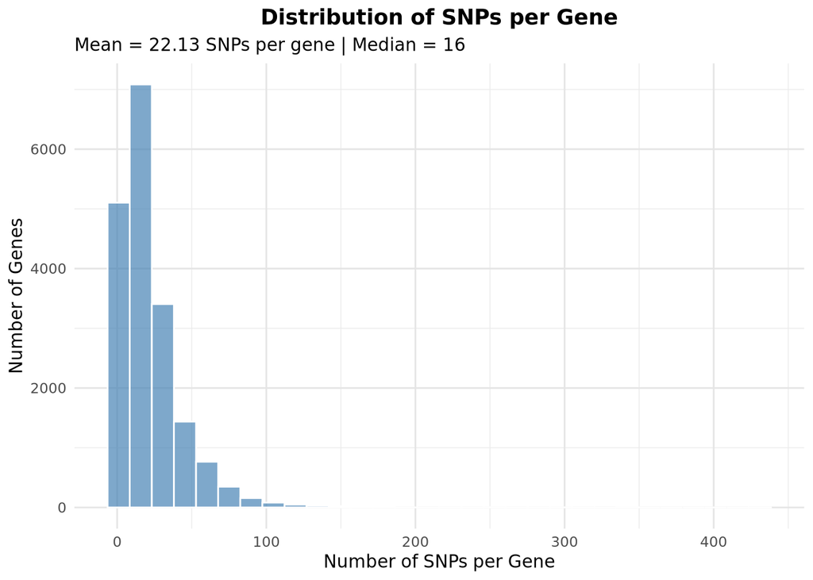

```r
if(nrow(snp_gene_map) > 0 && nrow(snp_gene_map) > 1) {
  # Calculate SNPs per gene distribution
  snps_per_gene <- table(snp_gene_map$gene_id)
  snps_per_gene_df <- data.frame(
    gene_id = names(snps_per_gene),
    nsnp = as.numeric(snps_per_gene)
  )

  p_overlap_dist <- ggplot(snps_per_gene_df, aes(x = nsnp)) +
    geom_histogram(bins = 30, fill = "steelblue", alpha = 0.7, color = "white") +
    labs(
      title = "Distribution of SNPs per Gene",
      subtitle = paste("Mean =", round(mean(snps_per_gene_df$nsnp), 2),
                       "SNPs per gene | Median =", median(snps_per_gene_df$nsnp)),
      x = "Number of SNPs per Gene",
      y = "Number of Genes"
    ) +
    theme_minimal(base_size = 11) +
    theme(
      panel.grid.major = element_line(color = "gray90"),
      plot.title = element_text(face = "bold", hjust = 0.5)
    )

  print(p_overlap_dist)

} else {
  cat("  Skipping overlap plot - insufficient data\n")
}
```

```r
cat("  Total SNP-gene pairs:", nrow(snp_gene_map), "\n")
```

```
##   Total SNP-gene pairs: 409705
```

```r
cat("  Unique genes with SNPs:", length(unique(snp_gene_map$gene_id)), "\n")
```

```
##   Unique genes with SNPs: 18514
```

```r
cat("  Candidate SNPs in genes:", sum(snp_gene_map$is_candidate), "\n")
```

```
##   Candidate SNPs in genes: 22483
```

```r
cat("\n Gene annotation and mapping complete!\n")
```

```
##
##  Gene annotation and mapping complete!
```

```r
cat("===========================================\n")
```

# 4. Identify Candidate Genes

- **PURPOSE:** Aggregate SNP-level signals to gene-level evidence of selection
- **BIOLOGICAL LOGIC:** Genes with multiple high-FST SNPs or extremely high FST values at key positions are stronger candidates for selection.
- **STATISTICAL LOGIC:** Using maximum FST per gene (classic outlier approach) focuses on the strongest signals. Alternative: mean FST for polygenic adaptation.

```r
cat("\nStep 4: Identifying candidate genes under selection...\n")
```

```
##
## Step 4: Identifying candidate genes under selection...
```

```r
# Aggregate SNP-level FST to gene-level statistics
gene_fst_summary <- snp_gene_map %>%
  group_by(gene_id) %>%
  summarise(
    max_FST    = max(FST, na.rm = TRUE),
    mean_FST   = mean(FST, na.rm = TRUE),
    median_FST = median(FST, na.rm = TRUE),
    nsnp       = n(),
    .groups    = "drop"
  )

# Choose statistic based on biological question
fst_statistic <- "max_FST"   # justified below

# Define candidate genes as top X% of genes
candidate_threshold <- quantile(
  gene_fst_summary[[fst_statistic]],
  config$fst_quantile,
  na.rm = TRUE
)

candidate_genes <- gene_fst_summary %>%
  filter(.data[[fst_statistic]] >= candidate_threshold) %>%
  arrange(desc(.data[[fst_statistic]]))

cat("  Total genes tested:", nrow(gene_fst_summary), "\n")
```

```
##   Total genes tested: 18514
```

```r
cat("  Candidate genes (top ",(1 - config$fst_quantile) * 100,"%): ",nrow(candidate_genes),"\n",sep = "")
```

```
##   Candidate genes (top 5%): 926
```

```r
cat("  Top candidate gene:",
    candidate_genes$gene_id[1],
    "with", fst_statistic, "=",
    round(candidate_genes[[fst_statistic]][1], 4), "\n")
```

```
##   Top candidate gene: AT4G02733 with max_FST = 0.7917
```

# 5. GO Enrichment Analysis

- **PURPOSE:** Create input for functional enrichment analysis
- **BIOLOGICAL LOGIC:** Tests whether certain biological processes are over-represented among selected genes compared to genome background.
- **STATISTICAL LOGIC:** Uses gene scores (FST values) to rank genes, with top quantile considered “selected” for enrichment testing.

```r
cat("\nStep 5.1: Preparing for GO enrichment analysis...\n")
```

```
##
## Step 5.1: Preparing for GO enrichment analysis...
```

```r
# ---------------------------
# 5.1. GENE SCORES AND UNIVERSE
# ---------------------------

# Gene universe: all genes with ≥1 SNP tested
all_genes <- unique(snp_gene_map$gene_id)

# Gene-level scores: MAX FST per gene (consistent with Step 4)
gene_fst_scores <- snp_gene_map %>%
  group_by(gene_id) %>%
  summarise(max_FST = max(FST, na.rm = TRUE), .groups = "drop")

gene_vector <- gene_fst_scores$max_FST
names(gene_vector) <- gene_fst_scores$gene_id

# Restrict to genes present in org.At.tair.db
arabidopsis_genes <- keys(org.At.tair.db)
gene_vector_filtered <- gene_vector[names(gene_vector) %in% arabidopsis_genes]

cat("  Genes in analysis:", length(gene_vector_filtered), "\n")
```

```
##   Genes in analysis: 18514
```

```r
cat("  Genes NOT in Arabidopsis database:",
    length(gene_vector) - length(gene_vector_filtered), "\n")
```

```
##   Genes NOT in Arabidopsis database: 0
```

```r
# ---------------------------
# 5.2. GO ENRICHMENT (FISHER + KS)
# ---------------------------

cat("\nStep 5.2: Running GO enrichment analysis...\n")
```

```
##
## Step 5.2: Running GO enrichment analysis...
```

```r
# Selection function: top X% of genes by MAX FST
selection_function <- function(allScores) {
  threshold <- quantile(
    allScores,
    config$fst_quantile,   ### FIX: correct config variable
    na.rm = TRUE
  )
  allScores >= threshold
}

# Create topGO object
tGOdata <- new(
  "topGOdata",
  ontology = config$ontology,
  allGenes = gene_vector_filtered,
  geneSel  = selection_function,
  nodeSize = config$node_size,
  annot    = annFUN.org,
  mapping  = "org.At.tair.db",
  description = "GO enrichment of high-FST genes (SWE vs ESP)"
)

# Run tests
cat("  Running Fisher's exact test...\n")
```

```
##   Running Fisher's exact test...
```

```r
results_fisher <- runTest(tGOdata,
                          algorithm = config$algorithm,
                          statistic = "fisher")

cat("  Running Kolmogorov-Smirnov test...\n")
```

```
##   Running Kolmogorov-Smirnov test...
```

```r
results_ks <- runTest(tGOdata,
                      algorithm = config$algorithm,
                      statistic = "ks")

# ---------------------------
# 5.3. RESULT TABLES
# ---------------------------

go_fisher <- GenTable(
  tGOdata,
  Fisher_p_value = results_fisher,
  orderBy = "Fisher_p_value",
  topNodes = length(score(results_fisher))
)

go_ks <- GenTable(
  tGOdata,
  KS_p_value = results_ks,
  orderBy = "KS_p_value",
  topNodes = length(score(results_ks))
)

# Convert p-values
go_fisher$Fisher_p_value <- as.numeric(go_fisher$Fisher_p_value)
go_ks$KS_p_value <- as.numeric(go_ks$KS_p_value)

# Merge results
go_enrichment <- merge(
  go_fisher[, c("GO.ID", "Term", "Annotated", "Significant", "Expected", "Fisher_p_value")],
  go_ks[, c("GO.ID", "KS_p_value")],
  by = "GO.ID",
  all.x = TRUE
)

# Multiple testing correction and metrics
go_enrichment <- go_enrichment %>%
  mutate(
    Fisher_FDR = p.adjust(Fisher_p_value, method = "BH"),
    KS_FDR = ifelse(!is.na(KS_p_value),
                    p.adjust(KS_p_value, method = "BH"),
                    NA),
    Enrichment_ratio = as.numeric(Significant) / as.numeric(Expected)
  ) %>%
  arrange(Fisher_p_value)

# ---------------------------
# 5.4. SUMMARY
# ---------------------------

cat("\n=== GO ENRICHMENT SUMMARY ===\n")
```

```
##
## === GO ENRICHMENT SUMMARY ===
```

```r
cat("  GO terms tested:", nrow(go_enrichment), "\n")
```

```
##   GO terms tested: 2122
```

```r
cat("  Fisher FDR < 0.05:",
    sum(go_enrichment$Fisher_FDR < 0.05, na.rm = TRUE), "\n")
```

```
##   Fisher FDR < 0.05: 0
```

```r
cat("  KS FDR < 0.05:",
    sum(go_enrichment$KS_FDR < 0.05, na.rm = TRUE), "\n")
```

```
##   KS FDR < 0.05: 1
```

```r
cat("\n  Top GO term (Fisher):",
    go_enrichment$Term[1], "\n")
```

```
##
##   Top GO term (Fisher): plant-type hypersensitive response
```

```r
cat("  Fisher p-value:",
    format(go_enrichment$Fisher_p_value[1], scientific = TRUE), "\n")
```

```
##   Fisher p-value: 7.4e-04
```

```r
cat("\n GO enrichment analysis complete!\n")
```

```
##
##  GO enrichment analysis complete!
```

# 6. Interactive GO Enrichment Table

```r
cat("\nDisplaying interactive GO enrichment table...\n")
```

```
##
## Displaying interactive GO enrichment table...
```

```r
# Use the authoritative GO enrichment object
table_data <- go_enrichment

# Create display-ready table
display_table <- table_data %>%
  mutate(
    # Numeric enrichment metric
    Enrichment = round(Enrichment_ratio, 2),

    # Fisher test (formatted for display)
    Fisher_p = format(Fisher_p_value, scientific = TRUE, digits = 2),
    Fisher_FDR = format(Fisher_FDR, scientific = TRUE, digits = 2),

    # KS test (formatted, with N/A where missing)
    KS_p = ifelse(!is.na(KS_p_value), format(KS_p_value, scientific = TRUE, digits = 2), "N/A"),
    KS_FDR = ifelse(!is.na(KS_FDR), format(KS_FDR, scientific = TRUE, digits = 2), "N/A"),

    # Combined significance based on numeric FDRs
    Combined = case_when(
      Fisher_FDR < 0.05 & !is.na(KS_FDR) & KS_FDR < 0.05 ~ "Both significant",
      Fisher_FDR < 0.05 ~ "Fisher only",
      !is.na(KS_FDR) & KS_FDR < 0.05 ~ "KS only",
      TRUE ~ "Neither"
    )
  ) %>%
  select(
    GO.ID,
    Term,
    Annotated,
    Significant,
    Expected,
    Enrichment,
    Fisher_p,
    Fisher_FDR,
    KS_p,
    KS_FDR,
    Combined
  )

# Create interactive DataTable
dt <- datatable(
  display_table,
  extensions = c("Buttons", "Scroller"),
  options = list(
    dom = "Bfrtip",
    buttons = c("copy", "csv", "excel", "pdf", "print"),
    pageLength = 20,
    scrollX = TRUE,
    scrollY = "600px",
    scroller = TRUE
  ),
  rownames = FALSE
)

dt
```

| GO.ID | Term | Annotated | Significant | Expected | Enrichment | Fisher_p | Fisher_FDR | KS_p | KS_FDR | Combined |
| --- | --- | --- | --- | --- | --- | --- | --- | --- | --- | --- |
| GO:0009626 | plant-type hypersensitive response | 90 | 13 | 4.68 | 2.78 | 7.4e-04 | 6.3e-01 | 9.9e-01 | 1.0e+00 | Neither |
| GO:0010214 | seed coat development | 39 | 8 | 2.03 | 3.94 | 7.6e-04 | 6.3e-01 | 1.0e+00 | 1.0e+00 | Neither |
| GO:0006473 | protein acetylation | 10 | 4 | 0.52 | 7.69 | 1.2e-03 | 6.3e-01 | 9.4e-01 | 1.0e+00 | Neither |
| GO:0034599 | cellular response to oxidative stress | 63 | 10 | 3.28 | 3.05 | 1.4e-03 | 6.3e-01 | 9.2e-01 | 1.0e+00 | Neither |
| GO:0031365 | N-terminal protein amino acid modificati... | 47 | 10 | 2.45 | 4.08 | 1.8e-03 | 6.3e-01 | 9.8e-01 | 1.0e+00 | Neither |
| GO:0090615 | mitochondrial mRNA processing | 11 | 4 | 0.57 | 7.02 | 1.8e-03 | 6.3e-01 | 1.0e+00 | 1.0e+00 | Neither |
| GO:0006950 | response to stress | 2672 | 182 | 139.04 | 1.31 | 2.2e-03 | 6.5e-01 | 1.0e+00 | 1.0e+00 | Neither |
| GO:1902182 | shoot apical meristem development | 12 | 4 | 0.62 | 6.45 | 2.6e-03 | 6.5e-01 | 9.8e-01 | 1.0e+00 | Neither |
| GO:0042762 | regulation of sulfur metabolic process | 28 | 6 | 1.46 | 4.11 | 2.7e-03 | 6.5e-01 | 8.6e-01 | 1.0e+00 | Neither |
| GO:0080156 | mitochondrial mRNA modification | 20 | 5 | 1.04 | 4.81 | 3.0e-03 | 6.5e-01 | 9.8e-01 | 1.0e+00 | Neither |

[output cut: 2112 more lines]

# 7. Visualisation of Enriched GO Terms

```r
# ---------------------------
# 7.1. PREPARE DATA FOR BOTH TESTS
# ---------------------------
cat("Preparing data for both Fisher and KS tests...\n")
```

```
## Preparing data for both Fisher and KS tests...
```

```r
# Use authoritative GO enrichment object
go_results <- go_enrichment

# Ensure KS columns exist
if(!"KS_p_value" %in% names(go_results)) {
  go_results$KS_p_value <- NA
  go_results$KS_FDR <- NA
}

# Sort by KS p-value for KS plot
go_results_ks <- go_results %>% arrange(KS_p_value)

# Calculate Significant/Expected ratio and labels
go_results <- go_results %>%
  mutate(
    Sig_Expected_ratio = Significant / Expected,
    Sig_Expected_label = paste0(round(Significant, 0), "/", round(Expected, 1))
  )

go_results_ks <- go_results_ks %>%
  mutate(
    Sig_Expected_ratio = Significant / Expected,
    Sig_Expected_label = paste0(round(Significant, 0), "/", round(Expected, 1))
  )

# Select top terms for each test
ntop <- min(10, nrow(go_results))
ggdata_Fisher <- go_results[1:ntop, ]
ggdata_Fisher$Term <- factor(ggdata_Fisher$Term, levels = rev(unique(ggdata_Fisher$Term)))

ggdata_KS <- go_results_ks[1:ntop, ]
# Use unique levels to avoid duplicates
ggdata_KS$Term <- factor(ggdata_KS$Term, levels = rev(unique(ggdata_KS$Term)))

cat("Using top", ntop, "terms for each test\n")
```

```
## Using top 10 terms for each test
```

```r
# ---------------------------
# 7.2. CREATE FISHER TEST PLOT
# ---------------------------
cat("\nCreating Fisher test plot...\n")
```

```
##
## Creating Fisher test plot...
```

```r
p_fisher <- ggplot(ggdata_Fisher, aes(x = Fisher_p_value, y = Term,
                                      size = Sig_Expected_ratio,  # Use Sig/Expected ratio for size
                                      color = Fisher_p_value)) +
  geom_point(alpha = 0.7, stroke = 0.5) +  # Added stroke for better visibility
  # Changed label to Significant/Expected
  geom_text(aes(label = Sig_Expected_label),
            vjust = 0.5, hjust = 0.5, size = 3,
            color = "black", fontface = "bold") +  # Black text as requested
  scale_size_continuous(
    name = "Ratio\n(Sig/Exp)",
    range = c(5, 19),
    breaks = pretty(range(ggdata_Fisher$Sig_Expected_ratio), n = 3)
  ) +
  scale_color_continuous(
    low = "red",
    high = "gold",
    name = "p-value\n(red=less sig)",
    guide = guide_colorbar(reverse = TRUE)
  ) +
  theme_minimal() +
  labs(
    x = "Fisher p-value (more significant→)",
    y = "GO Terms",
    title = "GO Enrichment - Fisher Exact Test",
    subtitle = paste("Top", ntop, "terms | Bubble size = Significant/Expected | Black labels = Sig/Exp")
  ) +
  theme(
    panel.border = element_rect(color = "grey", fill = NA, size = 1),
    legend.position = "right",
    legend.box = "vertical",
    axis.text = element_text(size = 10),
    axis.title = element_text(size = 10),
    plot.title = element_text(hjust = 0.5, face = "bold", size = 12),
    plot.subtitle = element_text(hjust = 0.5, color = "gray40", size = 9),
    legend.title = element_text(size = 9, face = "bold"),
    legend.text = element_text(size = 8)
  ) +
  scale_x_reverse() +
  # Add significance threshold line
  geom_vline(xintercept = 0.05, linetype = "dashed", color = "blue", alpha = 0.5, size = 0.5) +
  annotate("text", x = 0.05, y = ntop + 0.5,
         label = "p=0.05", color = "blue", size = 3, hjust = 1.2)
# ---------------------------
# 7.3. CREATE KS TEST PLOT
# ---------------------------
cat("Creating KS test plot...\n")
```

```
## Creating KS test plot...
```

```r
p_ks <- ggplot(ggdata_KS, aes(x = KS_p_value, y = Term,
                              size = Sig_Expected_ratio,
                              color = KS_p_value)) +
  geom_point(alpha = 0.7, stroke = 0.5) +
  geom_text(aes(label = Sig_Expected_label),
            vjust = 0.5, hjust = 0.5, size = 3,
            color = "black", fontface = "bold") +
  scale_size_continuous(
    name = "Ratio\n(Sig/Exp)",
    range = c(5, 19),
    breaks = pretty(range(ggdata_KS$Sig_Expected_ratio), n = 3)
  ) +
  scale_color_continuous(
    low = "red",
    high = "gold",
    name = "p-value\n(red=less sig)",
    guide = guide_colorbar(reverse = TRUE)
  ) +
  theme_minimal() +
  labs(
    x = "KS p-value (more significant→)",
    y = "GO Terms",
    title = "GO Enrichment - Kolmogorov-Smirnov Test",
    subtitle = paste("Top", ntop, "terms | Bubble size = Significant/Expected | Black labels = Sig/Exp")
  ) +
  theme(
    panel.border = element_rect(color = "grey", fill = NA, size = 1),
    legend.position = "right",
    legend.box = "vertical",
    axis.text = element_text(size = 10),
    axis.title = element_text(size = 10),
    plot.title = element_text(hjust = 0.5, face = "bold", size = 12),
    plot.subtitle = element_text(hjust = 0.5, color = "gray40", size = 9),
    legend.title = element_text(size = 9, face = "bold"),
    legend.text = element_text(size = 8)
  ) +
  scale_x_reverse() +
  # Add significance threshold line
  geom_vline(xintercept = 0.05, linetype = "dashed", color = "blue", alpha = 0.5, size = 0.5) +
  annotate("text", x = 0.05, y = ntop + 0.5,
         label = "p=0.05", color = "blue", size = 3, hjust = 1.2)
# ---------------------------
# 7.4. CREATE ENRICHMENT RATIO PLOT
# ---------------------------
cat("Creating enrichment ratio plot...\n")
```

```
## Creating enrichment ratio plot...
```